# Tutorial Exercise: Yelp reviews

## Introduction

This exercise uses a small subset of the data from Kaggle's [Yelp Business Rating Prediction](https://www.kaggle.com/c/yelp-recsys-2013) competition.

**Description of the data:**

- **`yelp.csv`** contains the dataset. It is stored in the repository (in the **`data`** directory), so there is no need to download anything from the Kaggle website.
- Each observation (row) in this dataset is a review of a particular business by a particular user.
- The **stars** column is the number of stars (1 through 5) assigned by the reviewer to the business. (Higher stars is better.) In other words, it is the rating of the business by the person who wrote the review.
- The **text** column is the text of the review.

**Goal:** Predict the star rating of a review using **only** the review text.

**Tip:** After each task, I recommend that you check the shape and the contents of your objects, to confirm that they match your expectations.

## Task 1

Read **`yelp.csv`** into a pandas DataFrame and examine it.

```python
import pandas as pd
```

```python
yelp = pd.read_csv('data/yelp.csv')
yelp.head()
```

|  | business_id | date | review_id | stars | text | type | user_id | cool | useful | funny |
| --- | --- | --- | --- | --- | --- | --- | --- | --- | --- | --- |
| 0 | 9yKzy9PApeiPPOUJEtnvkg | 2011-01-26 | fWKvX83p0-ka4JS3dc6E5A | 5 | My wife took me here on my birthday for breakf... | review | rLtl8ZkDX5vH5nAx9C3q5Q | 2 | 5 | 0 |
| 1 | ZRJwVLyzEJq1VAihDhYiow | 2011-07-27 | IjZ33sJrzXqU-0X6U8NwyA | 5 | I have no idea why some people give bad review... | review | 0a2KyEL0d3Yb1V6aivbIuQ | 0 | 0 | 0 |
| 2 | 6oRAC4uyJCsJl1X0WZpVSA | 2012-06-14 | IESLBzqUCLdSzSqm0eCSxQ | 4 | love the gyro plate. Rice is so good and I als... | review | 0hT2KtfLiobPvh6cDC8JQg | 0 | 1 | 0 |
| 3 | _1QQZuf4zZOyFCvXc0o6Vg | 2010-05-27 | G-WvGaISbqqaMHlNnByodA | 5 | Rosie, Dakota, and I LOVE Chaparral Dog Park!!... | review | uZetl9T0NcROGOyFfughhg | 1 | 2 | 0 |
| 4 | 6ozycU1RpktNG2-1BroVtw | 2012-01-05 | 1uJFq2r5QfJG_6ExMRCaGw | 5 | General Manager Scott Petello is a good egg!!!... | review | vYmM4KTsC8ZfQBg-j5MWkw | 0 | 0 | 0 |

```python
yelp.shape
```

```
(10000, 10)
```

```python
# Adding review length to find if there is any relation between stars and review length
yelp['review_length'] = yelp.text.apply(len)
yelp.head()
```

|  | business_id | date | review_id | stars | text | type | user_id | cool | useful | funny | review_length |
| --- | --- | --- | --- | --- | --- | --- | --- | --- | --- | --- | --- |
| 0 | 9yKzy9PApeiPPOUJEtnvkg | 2011-01-26 | fWKvX83p0-ka4JS3dc6E5A | 5 | My wife took me here on my birthday for breakf... | review | rLtl8ZkDX5vH5nAx9C3q5Q | 2 | 5 | 0 | 889 |
| 1 | ZRJwVLyzEJq1VAihDhYiow | 2011-07-27 | IjZ33sJrzXqU-0X6U8NwyA | 5 | I have no idea why some people give bad review... | review | 0a2KyEL0d3Yb1V6aivbIuQ | 0 | 0 | 0 | 1345 |
| 2 | 6oRAC4uyJCsJl1X0WZpVSA | 2012-06-14 | IESLBzqUCLdSzSqm0eCSxQ | 4 | love the gyro plate. Rice is so good and I als... | review | 0hT2KtfLiobPvh6cDC8JQg | 0 | 1 | 0 | 76 |
| 3 | _1QQZuf4zZOyFCvXc0o6Vg | 2010-05-27 | G-WvGaISbqqaMHlNnByodA | 5 | Rosie, Dakota, and I LOVE Chaparral Dog Park!!... | review | uZetl9T0NcROGOyFfughhg | 1 | 2 | 0 | 419 |
| 4 | 6ozycU1RpktNG2-1BroVtw | 2012-01-05 | 1uJFq2r5QfJG_6ExMRCaGw | 5 | General Manager Scott Petello is a good egg!!!... | review | vYmM4KTsC8ZfQBg-j5MWkw | 0 | 0 | 0 | 469 |

```python
yelp.info()
```

```
<class 'pandas.core.frame.DataFrame'>
RangeIndex: 10000 entries, 0 to 9999
Data columns (total 11 columns):
business_id      10000 non-null object
date             10000 non-null object
review_id        10000 non-null object
stars            10000 non-null int64
text             10000 non-null object
type             10000 non-null object
user_id          10000 non-null object
cool             10000 non-null int64
useful           10000 non-null int64
funny            10000 non-null int64
review_length    10000 non-null int64
dtypes: int64(5), object(6)
memory usage: 859.5+ KB
```

```python
yelp.describe()
```

|  | stars | cool | useful | funny | review_length |
| --- | --- | --- | --- | --- | --- |
| count | 10000.000000 | 10000.000000 | 10000.000000 | 10000.000000 | 10000.000000 |
| mean | 3.777500 | 0.876800 | 1.409300 | 0.701300 | 710.738700 |
| std | 1.214636 | 2.067861 | 2.336647 | 1.907942 | 617.399827 |
| min | 1.000000 | 0.000000 | 0.000000 | 0.000000 | 1.000000 |
| 25% | 3.000000 | 0.000000 | 0.000000 | 0.000000 | 294.000000 |
| 50% | 4.000000 | 0.000000 | 1.000000 | 0.000000 | 541.500000 |
| 75% | 5.000000 | 1.000000 | 2.000000 | 1.000000 | 930.000000 |
| max | 5.000000 | 77.000000 | 76.000000 | 57.000000 | 4997.000000 |

```python
# checking the distribution of stars with normalization
yelp.stars.value_counts(normalize=True)
```

```
4    0.3526
5    0.3337
3    0.1461
2    0.0927
1    0.0749
Name: stars, dtype: float64
```

```python
# Unique users who rated
yelp.user_id.nunique()
```

```
6403
```

```python
yelp.user_id.value_counts()[:10]
```

```
fczQCSmaWF78toLEmb0Zsw    38
0CMz8YaO3f8xu4KqQgKb9Q    25
90a6z--_CUrl84aCzZyPsg    22
4ozupHULqGyO42s3zNUzOQ    18
0mqHhdKEdak_A1FBhFNXqA    18
wHg1YkCzdZq9WBJOTRgxHQ    17
0bNXP9quoJEgyVZu9ipGgQ    16
_PzSNcfrCjeBxSLXRoMmgQ    16
JgDkCER12uiv4lbpmkZ9VA    15
joIzw_aUiNvBTuGoytrH7g    15
Name: user_id, dtype: int64
```

```python
yelp.type.value_counts()
```

```
review    10000
Name: type, dtype: int64
```

```python
yelp.columns
```

```
Index(['business_id', 'date', 'review_id', 'stars', 'text', 'type', 'user_id',
       'cool', 'useful', 'funny', 'review_length'],
      dtype='object')
```

```python
# Since all are reviews ignoring type feature
features = ['stars','text','cool','useful','funny','review_length']

yelp_modified =yelp[features]
yelp_modified.head()
```

|  | stars | text | cool | useful | funny | review_length |
| --- | --- | --- | --- | --- | --- | --- |
| 0 | 5 | My wife took me here on my birthday for breakf... | 2 | 5 | 0 | 889 |
| 1 | 5 | I have no idea why some people give bad review... | 0 | 0 | 0 | 1345 |
| 2 | 4 | love the gyro plate. Rice is so good and I als... | 0 | 1 | 0 | 76 |
| 3 | 5 | Rosie, Dakota, and I LOVE Chaparral Dog Park!!... | 1 | 2 | 0 | 419 |
| 4 | 5 | General Manager Scott Petello is a good egg!!!... | 0 | 0 | 0 | 469 |

## Task 2

Create a new DataFrame that only contains the **5-star** and **1-star** reviews.

- **Hint:** [How do I apply multiple filter criteria to a pandas DataFrame?](http://nbviewer.jupyter.org/github/justmarkham/pandas-videos/blob/master/pandas.ipynb#9.-How-do-I-apply-multiple-filter-criteria-to-a-pandas-DataFrame%3F-%28video%29) explains how to do this.

```python
# alias to make it easy while doing boolean indexing
y = yelp_modified

top_yelp = y[(y['stars'] == 5) | (y['stars'] == 1)]
print(top_yelp.shape)
top_yelp.head()
```

```
(4086, 6)
```

|  | stars | text | cool | useful | funny | review_length |
| --- | --- | --- | --- | --- | --- | --- |
| 0 | 5 | My wife took me here on my birthday for breakf... | 2 | 5 | 0 | 889 |
| 1 | 5 | I have no idea why some people give bad review... | 0 | 0 | 0 | 1345 |
| 3 | 5 | Rosie, Dakota, and I LOVE Chaparral Dog Park!!... | 1 | 2 | 0 | 419 |
| 4 | 5 | General Manager Scott Petello is a good egg!!!... | 0 | 0 | 0 | 469 |
| 6 | 5 | Drop what you're doing and drive here. After I... | 7 | 7 | 4 | 1565 |

## It seems 68% of the reviews are having ratings 4 and 5

```python
%matplotlib inline
```

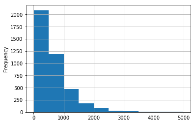

```python
top_yelp.review_length.plot(kind= 'hist',bins=10,grid=True)
```

```python
top_yelp[top_yelp['review_length']>4000]
```

|  | stars | text | cool | useful | funny | review_length |
| --- | --- | --- | --- | --- | --- | --- |
| 629 | 5 | FINALMENTE!!!\n\nAndiamo....\n\nFOOD\n--------... | 17 | 16 | 13 | 4264 |
| 1656 | 1 | Let me start by saying after my experience I s... | 0 | 1 | 0 | 4618 |
| 2311 | 5 | Pizzeria Bianco: Before and After \nCited as "... | 4 | 5 | 2 | 4795 |
| 2622 | 5 | Owned and operated by Eugenia Theodosopoulos (... | 2 | 3 | 3 | 4986 |
| 3655 | 1 | I play squash racquet's, a sport favored by th... | 12 | 10 | 17 | 4433 |
| 4796 | 1 | We were excited to check out this new restaura... | 1 | 5 | 0 | 4477 |
| 4849 | 5 | I rarely give 5 stars, as I believe it is very... | 5 | 7 | 2 | 4379 |
| 5263 | 1 | Had some time to kill before the Ultimate pleY... | 4 | 7 | 2 | 4401 |
| 6611 | 5 | Wow. Wow Freakin' Wow.\n\nI have never, ever h... | 2 | 2 | 4 | 4960 |
| 7575 | 5 | With a few hours past and a few tasks accompli... | 3 | 6 | 2 | 4121 |
| 8050 | 1 | "No." \n\nIf you ask me about eating at Papay... | 0 | 1 | 1 | 4475 |
| 8556 | 5 | Had a fabulous time here with my husband celeb... | 0 | 2 | 1 | 4494 |

```python
# .loc[index,column]
print(top_yelp.loc[629,'text'])
```

```
FINALMENTE!!!

Andiamo....

FOOD
--------
Appetizer: Fritto Misto, which is a trio of fried appetizers. For the day, ours included a cheese, a stuffed olive, and whole leaves of broccolini. The cheese wedge was great (I wish I remembered what it was), and have you ever had a deep fried veal-stuffed olive? Very interesting. The flash-fried b…

Main: Orecchiette alla Puttanesca. Man. This is the real deal. Orecchiette is the "little ear" pasta and "alla puttanesca" means it's made "whore style".

And what a beautiful, classy, yet very vibrant whore she is.

The pasta was cooked just perfectly, and even though puttanesca sauce usually goes with a stringier pasta (spaghetti, linguini, etc.) it worked really well with the orecchiette.

And the sauce. Holy mother, this streetwalkin' hussy of a sauce with its 12 ingredients: capers, breadcrumbs, anchovy sauce, garlic, olives, basil, olive oil, and, uh, the other 5. The flavors were a perfect, clear-heeled harmony. Nothing overpowered the other. Subtle and humble home food. It really…

As for the servings, when I first got my bowl I was thinking, "oh ok, this is a European serving. I'm still going to be starving after this." And, um, nope. Why? Because I slowed down. I savored my meal, and took my time with the dish. And by the end, was I hungry? Not at all. I really enjoyed this …

SERVICE
-------------
Very friendly, efficient, and willing to go through the menu in detail and answer any more questions about the restaurant. Dishes were brought out in a timely manner and there was never any rush after the meal was completed to clear the table.

And the mood inside Pastabar was palpable. Everyone looked happy, excited, and relieved that the restaurant was finally open for business. And I felt the same for them.

SETTING
-------------
I would say the space was just the right size. Not a cavernous place in the least. Probably the same size as Sens, maybe  even a little smaller. It's tucked away in the very back of the hallway of the building, so much so that I completely missed it when I was IN THE HALLWAY the previous afternoon l…

The colors inside are warm, with a modern bistro feel. No windows looking outside but I didn't mind that. There is seating at the bar, a few two-tops up front, and larger tables in the back. Selections from different Shins albums made up the soundtrack throughout the dinner, and while the music soun…

I definitely don't think this is going to be as "scene-y" as Sens. It has a completely different vibe.

EXTRA CRIB NOTES
-----------------------------
* the main courses of Pastabar are pasta and ONLY pasta. No veal parm here. And no hoikey sauces like Olive Garden-y alfredo or a jar of sugary Prego.
* It's great
* Prices for antipasti range from $7-$11-ish and mains $11-ish to $18. I spent around $26 with tax and a nice tip.
* it's great
* No liquor license (yet). For now, sparkling waters, lemonades, a number of sodas (including root beer & cream soda).
* it's great
* complimentary valet awaits the diners, if you're averse to parking close by yourself.
* it's great
* It's open till midnight on weeknights and 2 am on weekends! What more could you ask for?
* did I tell you it's great?

ALL IN ALL
---------------
An awesome asset to the area and I'm very content. And as much as I loved my whoreish little ears, all the other pastas on the menu sounded incredible and I can't wait to try them all.

I'm wishing these guys much success and giving them gratitude to finally being open. A few minor kinks to be worked out (and I wasn't as into the appetizer as I was my entree) so it's not totally perfect but they have started out very strong, and it's only Day 2.

And here I was thinking my days of giving out 5 stars were over (ok, more like 4.55 and rounding up)...
```

## Task 3

Define X and y from the new DataFrame, and then split X and y into training and testing sets, using the **review text** as the only feature and the **star rating** as the response.

- **Hint:** Keep in mind that X should be a pandas Series (not a DataFrame), since we will pass it to CountVectorizer in the task that follows.

```python
X= top_yelp.text
y=top_yelp.stars

print(X.shape)
print(y.shape)
```

```
(4086,)
(4086,)
```

```python
from sklearn.model_selection import train_test_split
```

```python
# random_state to reproduce results and 30% of data keeping aside for model evaluation
X_train,X_test,y_train,y_test = train_test_split(X,y,random_state = 42,test_size = 0.3)

print(X_train.shape)
print(X_test.shape)
```

```
(2860,)
(1226,)
```

```python
# Checking the distribution in train data
y_train.value_counts(normalize=True)
```

```
5    0.81958
1    0.18042
Name: stars, dtype: float64
```

```python
# Checking the distribution in test data
y_test.value_counts(normalize=True)
```

```
5    0.809951
1    0.190049
Name: stars, dtype: float64
```

## Task 4

Use CountVectorizer to create **document-term matrices** from X_train and X_test.

```python
from sklearn.feature_extraction.text import CountVectorizer
```

```python
# Ignoring terms which are occuring in half of the documents and also considering terms which are in atleast 2 documents
vectorizer = CountVectorizer(stop_words='english',max_df=0.5,min_df=2)
```

```python
X_train_dtm = vectorizer.fit_transform(X_train)

X_test_dtm = vectorizer.transform(X_test)

print(X_train_dtm.shape)
```

```
(2860, 8104)
```

## Task 5

Use multinomial Naive Bayes to **predict the star rating** for the reviews in the testing set, and then **calculate the accuracy** and **print the confusion matrix**.

- **Hint:** [Evaluating a classification model](https://github.com/justmarkham/scikit-learn-videos/blob/master/09_classification_metrics.ipynb) explains how to interpret both classification accuracy and the confusion matrix.

```python
from sklearn.naive_bayes import MultinomialNB
```

```python
%timeit?
```

```python
#Instantiating with default parameters
mNB = MultinomialNB()

%time mNB.fit(X_train_dtm,y_train)
```

```
Wall time: 8 ms
```

```
MultinomialNB(alpha=1.0, class_prior=None, fit_prior=True)
```

```python
y_pred = mNB.predict(X_test_dtm)

mNB.score(X_test_dtm,y_test)
```

```
0.9168026101141925
```

## Task 6 (Challenge)

Calculate the **null accuracy**, which is the classification accuracy that could be achieved by always predicting the most frequent class.

- **Hint:** [Evaluating a classification model](https://github.com/justmarkham/scikit-learn-videos/blob/master/09_classification_metrics.ipynb) explains null accuracy and demonstrates two ways to calculate it, though only one of those ways will work in this case. Alternatively, you can come up with your own method to calculate null accuracy!

```python
from sklearn.dummy import DummyClassifier
```

```python
# The below classifer will predict the most frequest class so that we can have a benchmark while evaluating
dummy = DummyClassifier(strategy='most_frequent')
dummy.fit(X_train_dtm,y_train)

dummy.score(X_test_dtm,y_test)
```

```
0.8099510603588908
```

## Task 7 (Challenge)

Browse through the review text of some of the **false positives** and **false negatives**. Based on your knowledge of how Naive Bayes works, do you have any ideas about why the model is incorrectly classifying these reviews?

- **Hint:** [Evaluating a classification model](https://github.com/justmarkham/scikit-learn-videos/blob/master/09_classification_metrics.ipynb) explains the definitions of "false positives" and "false negatives".
- **Hint:** Think about what a false positive means in this context, and what a false negative means in this context. What has scikit-learn defined as the "positive class"?

```python
from sklearn.metrics import confusion_matrix

confusion_matrix(y_test,y_pred)
```

```
array([[175,  58],
       [ 44, 949]], dtype=int64)
```

```python
# false positives
# Falsely predicted as positive

X_test[(y_pred > y_test)].head()
```

```
1406    From my door, it's a five minute stroll throug...
389     I really don't get why everyone is raving this...
2060                This place is closed.  Good riddance.
715     What's with the cheese?  It isn't even Velveta...
2839    Never Again,\nI brought my Mountain Bike in (w...
Name: text, dtype: object
```

```python
yelp_modified.loc[[1406,389],:]
```

|  | stars | text | cool | useful | funny | review_length |
| --- | --- | --- | --- | --- | --- | --- |
| 1406 | 1 | From my door, it's a five minute stroll throug... | 0 | 1 | 0 | 1551 |
| 389 | 1 | I really don't get why everyone is raving this... | 0 | 0 | 0 | 314 |

```python
# false negative
# falsely classified as negative [Here negative class is having low rating](So prediction is less than true)
X_test[(y_pred < y_test)].head()
```

```
2504    I've passed by prestige nails in walmart 100s ...
354     We happened upon this location when meeting a ...
4646    Wow, I am very impressed. The store is very bi...
2352    Everyone point and laugh at the nerd reviewing...
750     This store has the most pleasant employees of ...
Name: text, dtype: object
```

```python
yelp_modified.loc[[2504,354],:]
```

|  | stars | text | cool | useful | funny | review_length |
| --- | --- | --- | --- | --- | --- | --- |
| 2504 | 5 | I've passed by prestige nails in walmart 100s ... | 0 | 2 | 0 | 599 |
| 354 | 5 | We happened upon this location when meeting a ... | 0 | 0 | 0 | 846 |

## Task 8 (Challenge)

Calculate which 10 tokens are the most predictive of **5-star reviews**, and which 10 tokens are the most predictive of **1-star reviews**.

- **Hint:** Naive Bayes automatically counts the number of times each token appears in each class, as well as the number of observations in each class. You can access these counts via the `feature_count_` and `class_count_` attributes of the Naive Bayes model object.

```python
mNB.feature_count_
```

```
array([[27.,  4.,  3., ...,  0.,  1.,  0.],
       [36.,  5.,  1., ...,  7.,  9.,  3.]])
```

```python
mNB.class_count_
```

```
array([ 516., 2344.])
```

```python
obtained_features = vectorizer.get_feature_names()
```

```python
obtained_tokens = pd.DataFrame({'tokens':obtained_features,
                              '1 star':mNB.feature_count_[0],
                              '5 star':mNB.feature_count_[1]},columns = ['tokens','5 star','1 star'])

obtained_tokens.head()
```

|  | tokens | 5 star | 1 star |
| --- | --- | --- | --- |
| 0 | 00 | 36.0 | 27.0 |
| 1 | 000 | 5.0 | 4.0 |
| 2 | 00am | 1.0 | 3.0 |
| 3 | 00pm | 6.0 | 1.0 |
| 4 | 02 | 1.0 | 1.0 |

```python
top_tokens = obtained_tokens.sort_values(by= '5 star',ascending=False)
top_tokens.head()
```

|  | tokens | 5 star | 1 star |
| --- | --- | --- | --- |
| 5400 | place | 1371.0 | 324.0 |
| 3283 | great | 1364.0 | 67.0 |
| 2946 | food | 1177.0 | 408.0 |
| 3223 | good | 1162.0 | 196.0 |
| 4233 | like | 896.0 | 302.0 |

```python
worst_tokens = obtained_tokens.sort_values(by= '1 star',ascending=False)
worst_tokens.head()
```

|  | tokens | 5 star | 1 star |
| --- | --- | --- | --- |
| 2946 | food | 1177.0 | 408.0 |
| 5400 | place | 1371.0 | 324.0 |
| 4233 | like | 896.0 | 302.0 |
| 3994 | just | 888.0 | 279.0 |
| 6384 | service | 636.0 | 229.0 |

```python
# To workaround for the divide by 0 issue
obtained_tokens['5 star'] += 1
obtained_tokens['1 star'] += 1
```

```python
obtained_tokens['top_ratio'] = obtained_tokens['5 star']/obtained_tokens['1 star']
obtained_tokens['worst_ratio'] = obtained_tokens['1 star']/obtained_tokens['5 star']
```

```python
obtained_tokens.sort_values(by='top_ratio',ascending=False).head()
```

|  | tokens | 5 star | 1 star | top_ratio | worst_ratio |
| --- | --- | --- | --- | --- | --- |
| 2731 | fantastic | 184.0 | 1.0 | 184.000000 | 0.005435 |
| 5296 | perfect | 233.0 | 3.0 | 77.666667 | 0.012876 |
| 2689 | fabulous | 75.0 | 1.0 | 75.000000 | 0.013333 |
| 8085 | yum | 61.0 | 1.0 | 61.000000 | 0.016393 |
| 2754 | favorite | 290.0 | 5.0 | 58.000000 | 0.017241 |

```python
obtained_tokens.sort_values(by='worst_ratio',ascending=False).head()
```

|  | tokens | 5 star | 1 star | top_ratio | worst_ratio |
| --- | --- | --- | --- | --- | --- |
| 7566 | ugh | 1.0 | 13.0 | 0.076923 | 13.0 |
| 8081 | yuck | 1.0 | 13.0 | 0.076923 | 13.0 |
| 2890 | flavorless | 1.0 | 12.0 | 0.083333 | 12.0 |
| 806 | blah | 1.0 | 11.0 | 0.090909 | 11.0 |
| 922 | bouncers | 1.0 | 11.0 | 0.090909 | 11.0 |

## Task 9 (Challenge)

Up to this point, we have framed this as a **binary classification problem** by only considering the 5-star and 1-star reviews. Now, let's repeat the model building process using all reviews, which makes this a **5-class classification problem**.

Here are the steps:

- Define X and y using the original DataFrame. (y should contain 5 different classes.)
- Split X and y into training and testing sets.
- Create document-term matrices using CountVectorizer.
- Calculate the testing accuracy of a Multinomial Naive Bayes model.
- Compare the testing accuracy with the null accuracy, and comment on the results.
- Print the confusion matrix, and comment on the results. (This [Stack Overflow answer](http://stackoverflow.com/a/30748053/1636598) explains how to read a multi-class confusion matrix.)
- Print the [classification report](http://scikit-learn.org/stable/modules/model_evaluation.html#classification-report), and comment on the results. If you are unfamiliar with the terminology it uses, research the terms, and then try to figure out how to calculate these metrics manually from the confusion matrix!

```python
X1= yelp_modified.text
y1 = yelp_modified.stars

X1_train,X1_test,y1_train,y1_test = train_test_split(X1,y1,random_state = 42, test_size=0.3)


print(X1_train.shape)
print(X1_test.shape)

new_vectorizer = CountVectorizer(stop_words='english',ngram_range=(1,2),min_df=2,max_df=0.5)

print('learning tokens')
X1_train_dtm = new_vectorizer.fit_transform(X1_train)

print('transforming test set')
X1_test_dtm = new_vectorizer.transform(X1_test)

print('Model fitting')

nb = MultinomialNB()
nb.fit(X1_train_dtm,y1_train)

y1_pred = nb.predict(X1_test_dtm)

# f-strings which are part of python 3.5
print(f'accuracy :{nb.score(X1_test_dtm,y1_test)}')


confusion = confusion_matrix(y1_test,y1_pred)

new_features = new_vectorizer.get_feature_names()

print('Obtaining Dummy accuracy')

dummy2 = DummyClassifier(strategy='most_frequent')
dummy2.fit(X1_train_dtm,y1_train)

print(f'Dummy accuracy : {dummy2.score(X1_test_dtm,y1_test)}')
```

```
(7000,)
(3000,)
learning tokens
transforming test set
Model fitting
accuracy :0.49033333333333334
Obtaining Dummy accuracy
Dummy accuracy : 0.36233333333333334
```

```python
confusion
```

```
array([[ 53,  22,  16,  79,  48],
       [ 19,  26,  35, 147,  38],
       [  5,   5,  48, 318,  66],
       [  6,   3,  14, 769, 295],
       [  1,   0,   2, 410, 575]], dtype=int64)
```

```python
from sklearn.metrics import classification_report
```

```python
report = classification_report(y1_test,y1_pred)
```

```python
print(report)
```

```
             precision    recall  f1-score   support

          1       0.63      0.24      0.35       218
          2       0.46      0.10      0.16       265
          3       0.42      0.11      0.17       442
          4       0.45      0.71      0.55      1087
          5       0.56      0.58      0.57       988

avg / total       0.50      0.49      0.45      3000
```

```python
new_features = new_vectorizer.get_feature_names()
```

```python
len(new_features)
```

```
53270
```

```python
new_features[20000:20005]
```

```
['great eats',
 'great effort',
 'great employees',
 'great enjoyed',
 'great especially']
```